# Final Challenge: Plotting Agricultural and Protected Land on Oʻahu

Amber Camp

2024-10-17

This page is part of the final challenge for **GIS for Sustainability and Resilience, Vector Techniques in R**, a course led by Dr. Catherine Brockway.

# Introduction

The final challenge in this course was to create maps for a location that is personally important, focusing on issues of sustainability and/or resilience. I live on Oʻahu in Hawaiʻi and am constantly thinking about the supply-chain issues that affect our daily lives. I am particularly interested in how we feed ourselves: What can be grown here? What can local food production look like? How can we incentivize local food production and make it sustainable for producers, consumers, and the ʻāina?

I believe that strengthening the local food system is not only beneficial to our economy, but will also foster more connection to and appreciation for the land on which we live. For this reason, I am focusing on Oʻahu for this project.

Below, I will present maps that highlight agricultural land and protected lands. The goal is to see maps of the areas that could potentially be used for agricultural activity. These maps will not solve any sustainability issues alone, but I hope to present them as an introduction to the exploration of land use on the island.

Here is a map of Hawaiʻi, situated in the middle of the Pacific and circled in red.

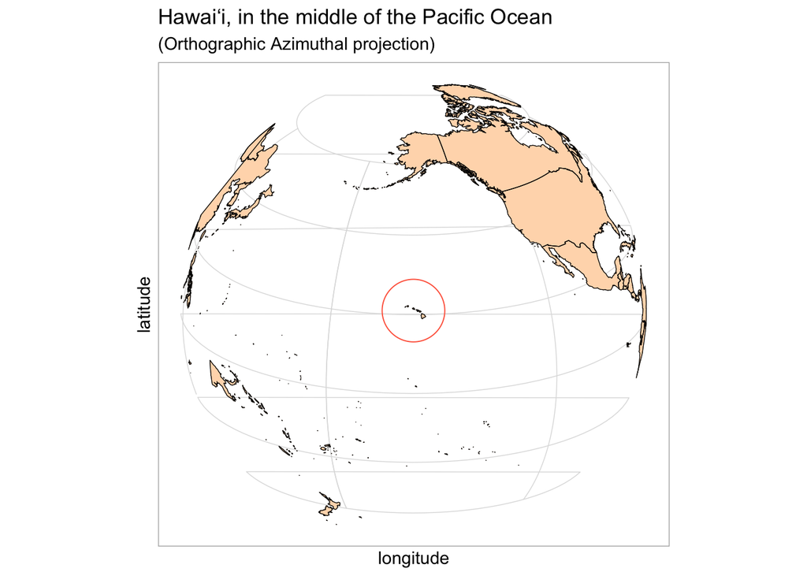

And below is a map of the primary islands in the pae ʻāina, or archipelago, of Hawaiʻi. This is what most people envision when they think of Hawaiʻi as a U.S. state. Each island is labeled.

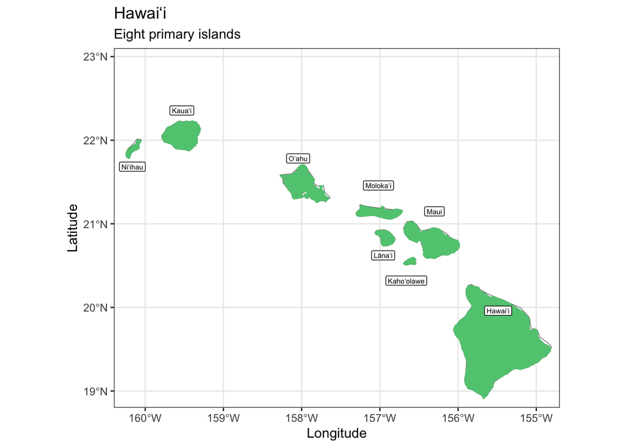

For the rest of the project, the focus will be on the island of Oʻahu, which encompasses Honolulu County.

# Agricultural Land on Oʻahu

The below map highlights areas on Oʻahu designated as agricultural land. This data comes from OpenStreetMap. I’m including features tagged as farmland, farmyard, allotments, and aquaculture.

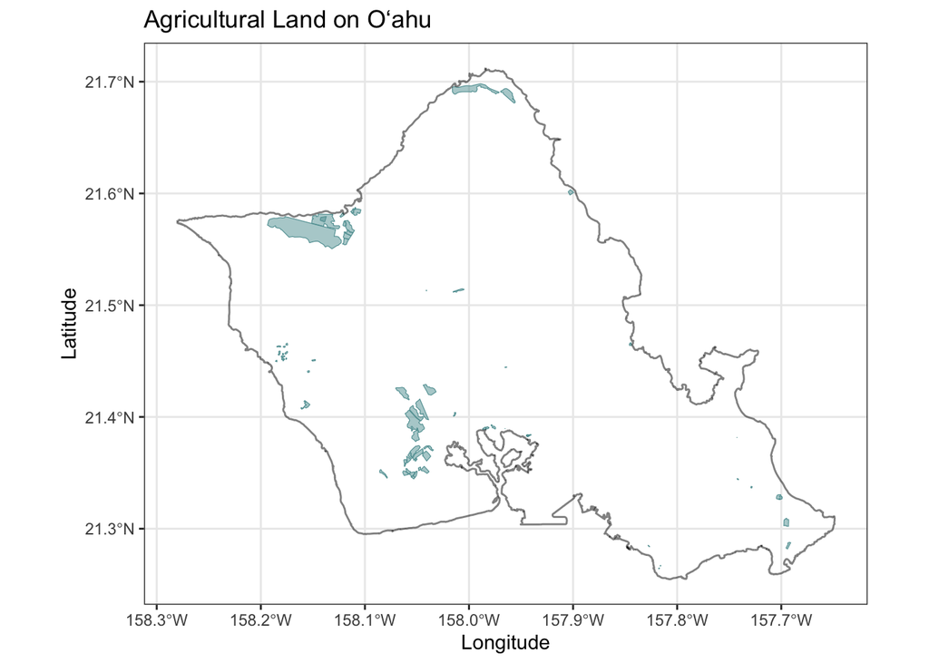

The blue areas on the map correspond to the agricultural land mentioned above. As you can see, there is not very much land area designated for agricultural use–at least not according to the data pulled from OpenStreetMap. From my personal experience and understanding, I believe we have much more land on island that is being used for food production purposes. This land may be private or may simply be missing from the dataset I referenced.

# Protected Areas on Oʻahu

This map highlights areas on Oʻahu designated as protected. This data also comes from OpenStreetMap, and will include land for national parks, marine protection areas, heritage sites, wilderness, cultural assets, and similar. For good measure, I’m also including nature reserves.

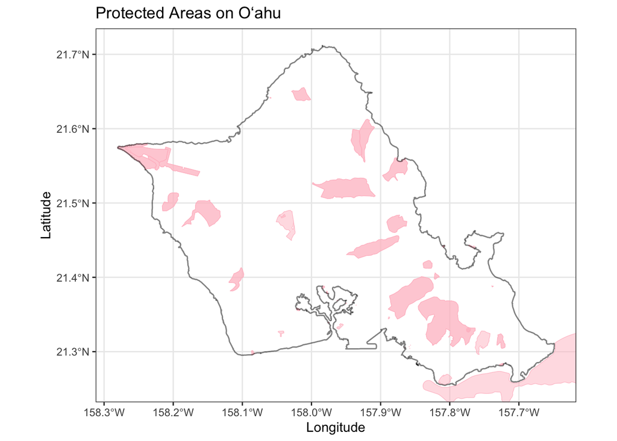

I’m happy to see that there are large areas on land and off the coast that are protected. The reason I wanted to map these was to compare the total protected and agricultural lands to the areas on the map that are not marked for these purposes.

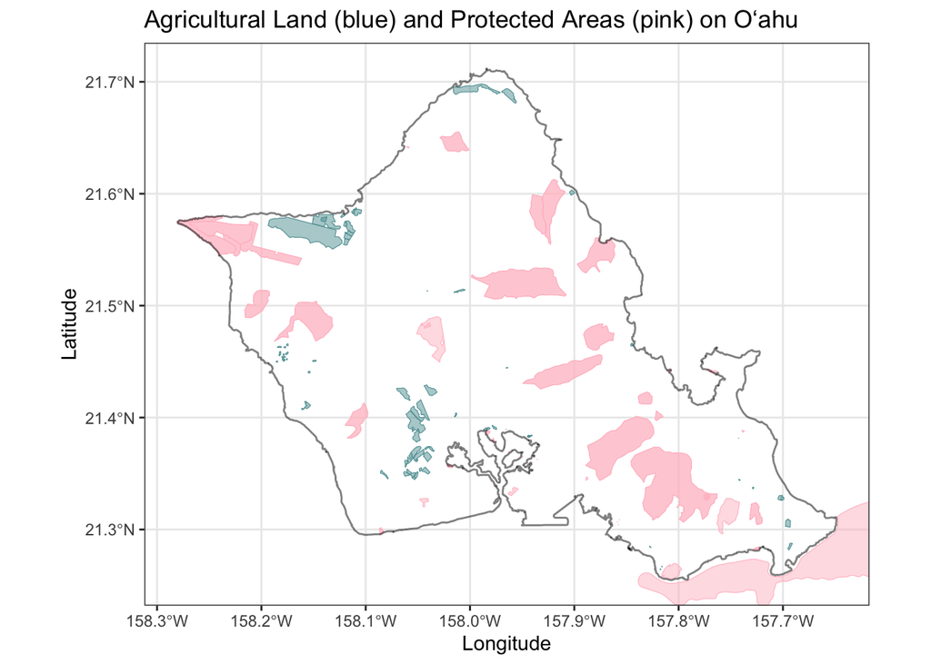

The above map is a combination of agricultural and protected areas. In building this map, I also remembered that there is quite a bit of land designated for military use. I’ve included these areas in brown below, along with adding surface roads for the purpose of contextualizing the landscape.

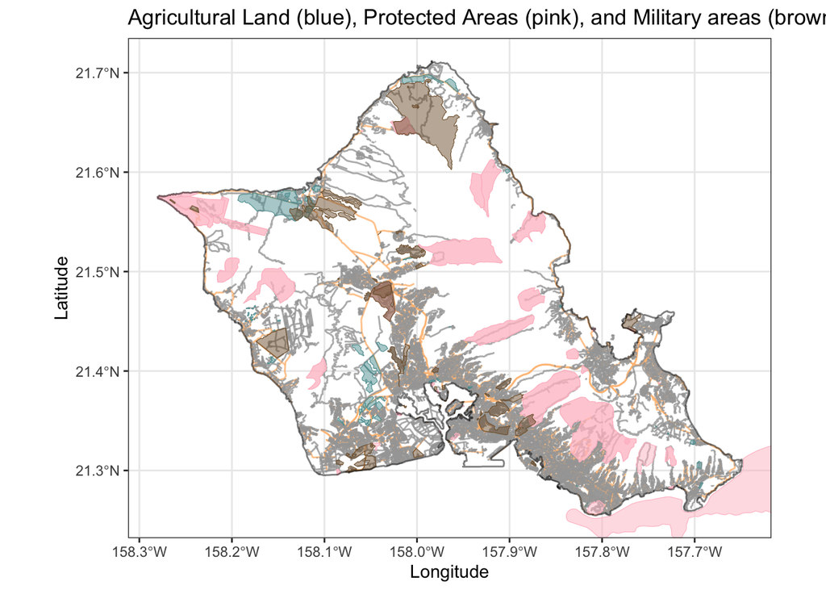

Interestingly, some of these areas even overlap.

One potential takeaway here is that there really isn’t very much agricultural land on the island. This could be a deficiency in the data, or a real-world limitation that can inhibit endeavors to become more sustainable in our food economy! This will require additional investigation.

I am not proposing here that all the unmarked land in white be available for agricultural activity. After all, much of the unmarked area is already being used for residential, educational, and commercial activity, or is mountainous terrain. I didn’t look at things like neighborhoods, cemeteries, or shopping centers, for example–but, obviously, that land would not be available for farming because it’s already occupied.

# Where are the fruit trees?

Having looked at land already being used (or not!) for agriculture, as well as additional land unavailable for use (due to protected or military status), I’m seeing some of the limitations for food production.

To piggyback off a previous project, I wanted to see what data was out there that may show where different fruit trees already are. I’m focusing on banana plants and mango trees for now, but we have an abundance of so many more types of produce growing in the “wild” potentially available for everyone that could also be mapped.

I will be using citizen science data from [iNaturalist](https://www.inaturalist.org) showing reported observations of these fruit locations. iNaturalist is a great resource where anyone can upload and explore information about real-life observations pertaining to biodiversity.

I am starting with the following iNaturalist data codes:

```r
place_id = 1856 # Honolulu County
bananas_id = 62911 # taxon id for genus bananas
mangos_id = 48875 # taxon id for genus mangifera
```

In the below map, I’ve removed some of the surface streets for easier visibility, but left more of the major streets to contextualize the places where people go. I’ve left the agricultural, protected, and military areas for reference.

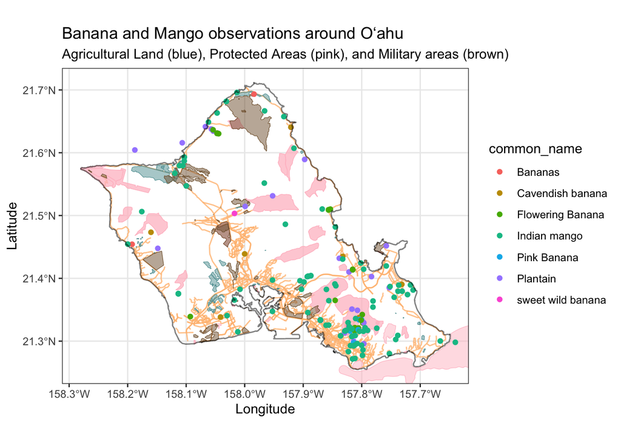

Look at all the bananas and mangoes around! I’m sure there are more, but this is a great start. After looking into some of the points that appear off the coast into the ocean and cross-checking with another map, it appears that their coordinates are slightly off. That’s okay! This was just an exploration.

Let’s try a different view:

[interactive chart not shown]

This map is much more interactive, and looks a lot more like the maps we are used to seeing on navigation apps like Google Maps. This draws information from iNaturalist as well as OpenStreetMap and Open Data Commons. You can click, drag, and zoom the map, and also click on the individual points for more information about what data was collected when, where, and by whom. I’ve set the data so that yellow dots are banana sightings and orange ones are for mangoes.

# Takeaways

I embarked on this project as a way to visualize what data is out there regarding land use, specifically for agricultural activity. Living here has given me an idea of where these lands are, but looking at potentially “official” information on a map can be an important step in understanding my surroundings. Additionally, on a map I could investigate where these lands are in relation to other features.

It’s not clear to me if the sparse representation of agricultural land is a limitation in the data source, data tagging, or data reporting, or if there is in reality a smaller area of agricultural land on island than I previously thought.

There is still a lot to learn about the food system here, and I have a few contacts I will be working with to develop programs for research and internships for interested students.

For now, I’ll just look for bananas and mangoes on my interactive map and see if any of them are public and accessible. Urban foraging can be one way to supplement other methods of addressing food insecurity and the local food economy after all.

# Resources

Here is a list of resources provided by Dr. Brockway for us all to continue our geospatial data journey. I’m leaving them here because I’d like to come back to them:

- [Spatial Data Science with R and “terra”](https://rspatial.org) Free tutorials. “These resources teach spatial data analysis and modeling with R. R is a widely used programming language and software environment for data science. R also provides unparalleled opportunities for analyzing spatial data and for spatial modeling.”
- [Spatial Data Science](https://r-spatial.org/book/) Free ebook. “This book introduces and explains the concepts underlying spatial data: points, lines, polygons, rasters, coverages, geometry attributes, data cubes, reference systems, as well as higher-level concepts including how attributes relate to geometries and how this affects analysis. … The book aims at data scientists who want to get a grip on using spatial data in their analysis. To exemplify how to do things, it uses R.”
- [Analyzing US Census Data: Methods, Maps, and Models in R](https://walker-data.com/census-r/index.html) Free ebook. Check out the rest of this book (we only covered a few chapters) for lots of great ideas for using US Census data. “Census data is widely used in the United States across numerous research and applied fields, including education, business, journalism, and many others. Until recently, the process of working with US Census data has required the use of a wide array of web interfaces and software platforms to prepare, map, and present data products. The goal of this book is to illustrate the utility of the R programming language for handling these tasks, allowing Census data users to manage their projects in a single computing environment.”